# Time Series with R

The random walk (RW) model is a special case of the autoregressive (AR) model, in which the slope parameter is equal to 1. Recall from previous chapters that the RW model is not stationary and exhibits very strong persistence. Its sample autocovariance function (ACF) also decays to zero very slowly, meaning past values have a long lasting impact on current values.

The stationary AR model has a slope parameter between -1 and 1. The AR model exhibits higher persistence when its slope parameter is closer to 1, but the process reverts to its mean fairly quickly. Its sample ACF also decays to zero at a quick (geometric) rate, indicating that values far in the past have little impact on future values of the process.

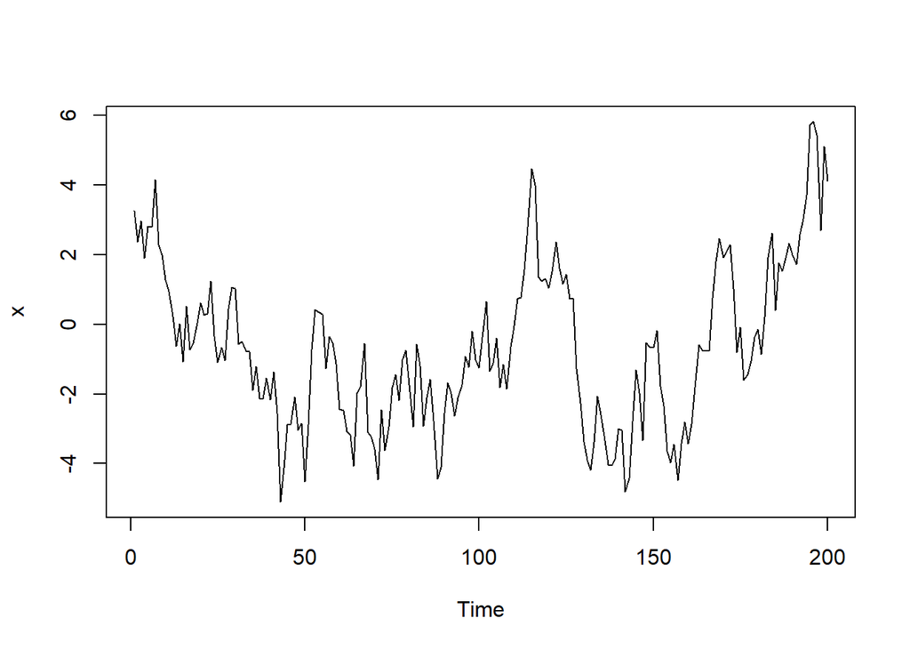

```r
# Simulate and plot AR model with slope 0.9
x <- arima.sim(model = list(ar = 0.9), n = 200)
ts.plot(x)
```

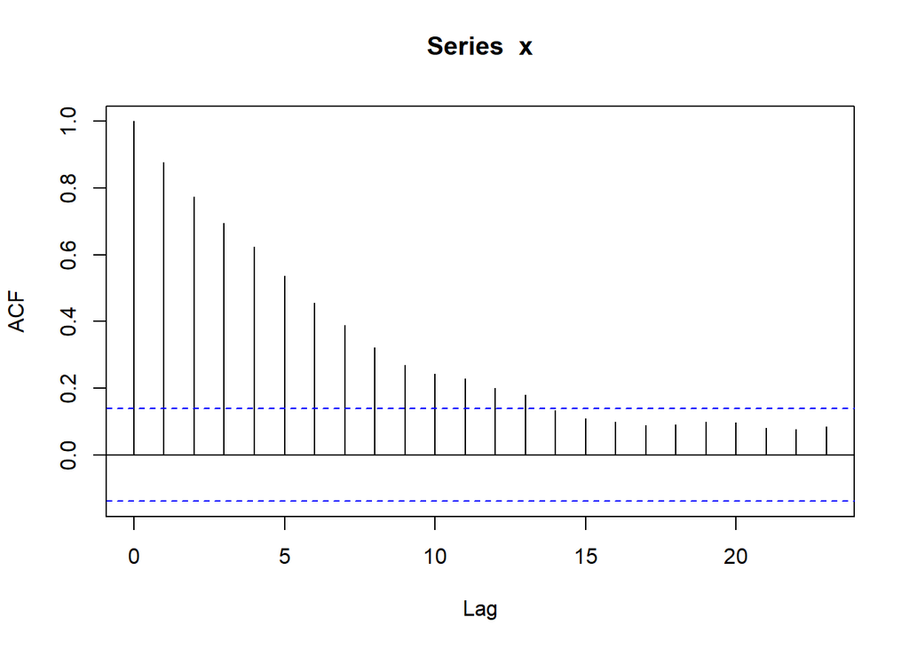

```r
acf(x)
```

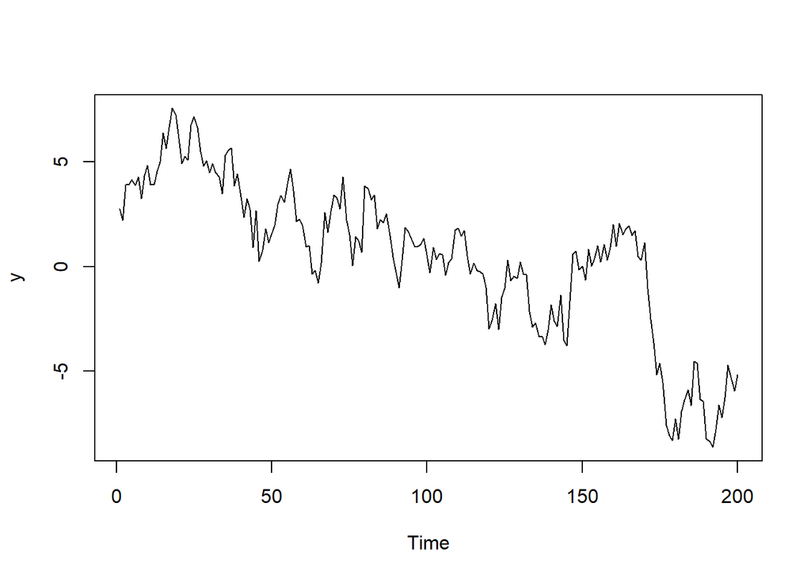

```r
# Simulate and plot AR model with slope 0.98
y <- arima.sim(model = list(ar = 0.98), n = 200)
ts.plot(y)
```

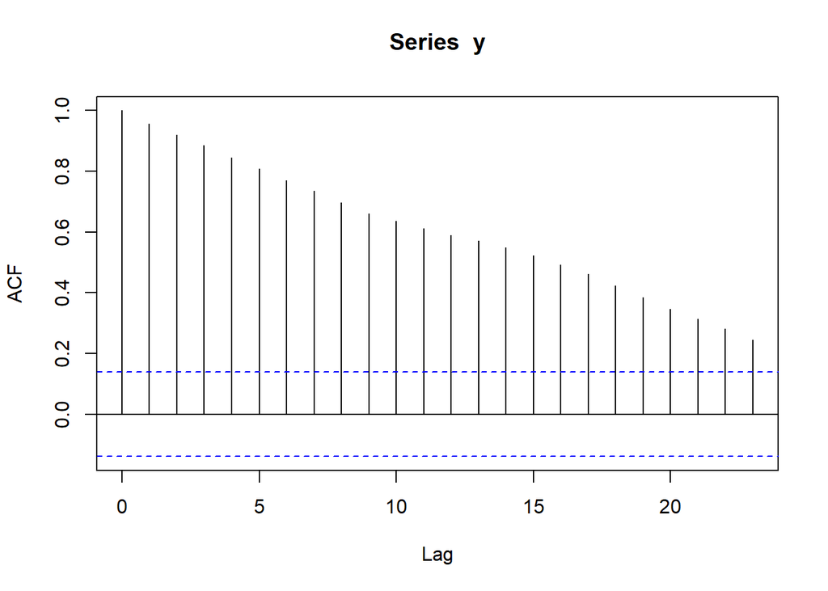

```r
acf(y)
```

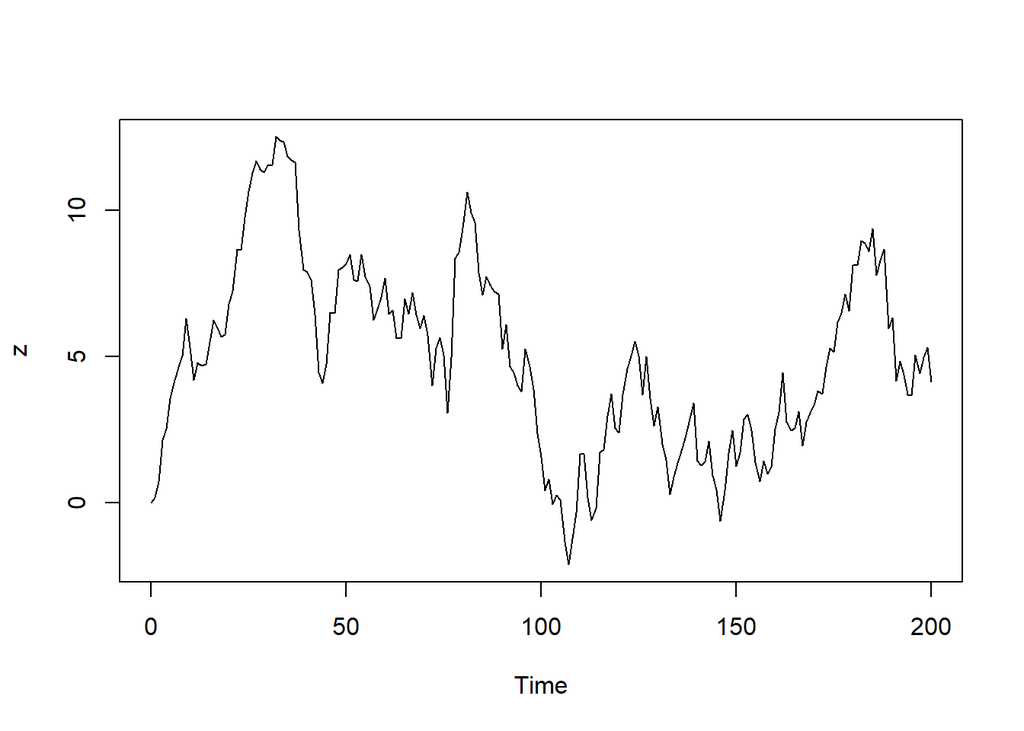

```r
# Simulate and plot RW model
z <- arima.sim(model = list(order = c(0, 1, 0)), n = 200)
ts.plot(z)
```

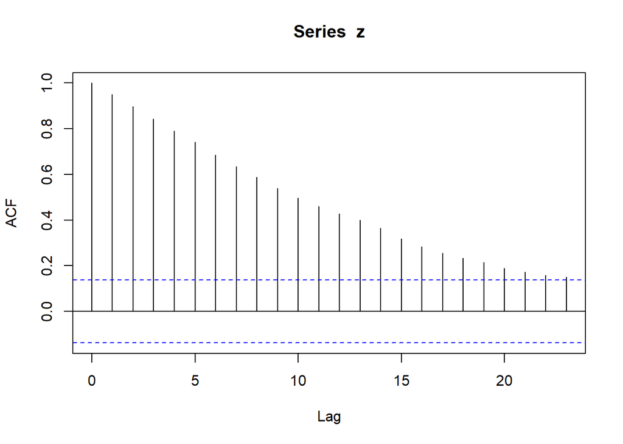

```r
acf(z)
```

As you can see, the AR model represented by series $y$ exhibits greater persistence than series $x$, but the ACF continues to decay to 0. By contrast, the RW model represented by series $z$ shows considerable persistence and relatively little decay in the ACF.

For a given time series x we can fit the autoregressive (AR) model using the `arima()` command and setting order equal to `c(1, 0, 0)`. Note for reference that an AR model is an ARIMA(1, 0, 0) model.

```r
# Fit the AR model to AirPassengers
AR <- arima(AirPassengers, order = c(1, 0, 0))
print(AR)
```

```
##
## Call:
## arima(x = AirPassengers, order = c(1, 0, 0))
##
## Coefficients:
##          ar1  intercept
##       0.9646   278.4649
## s.e.  0.0214    67.1141
##
## sigma^2 estimated as 1119:  log likelihood = -711.09,  aic = 1428.18
```

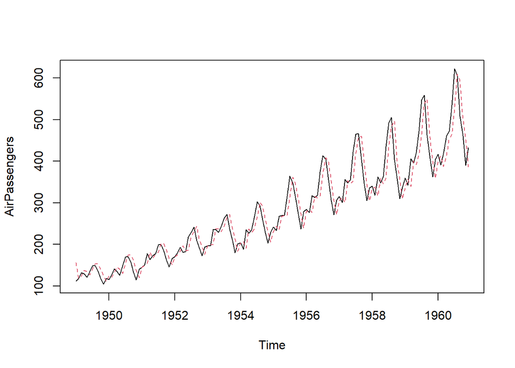

```r
# Run the following commands to plot the series and fitted values
ts.plot(AirPassengers)
AR_fitted <- AirPassengers - residuals(AR)
points(AR_fitted, type = "l", col = 2, lty = 2)
```

By fitting an AR model to the AirPassengers data, you’ve succesfully modeled the data in a reproducible fashion. This allows you to predict future observations based on your AR_fitted data.

The `predict()` function can be used to make forecasts from an estimated AR model.

```r
# Use predict() to make a 1-step forecast
predict_AR <- predict(AR)

# Obtain the 1-step forecast using $pred[1]
predict_AR$pred[1]
```

```
## [1] 426.5698
```

```r
# Use predict to make 1-step through 10-step forecasts
predict(AR, n.ahead = 10)
```

```
## $pred
##           Jan      Feb      Mar      Apr      May      Jun      Jul      Aug
## 1961 426.5698 421.3316 416.2787 411.4045 406.7027 402.1672 397.7921 393.5717
##           Sep      Oct
## 1961 389.5006 385.5735
##
## $se
##           Jan      Feb      Mar      Apr      May      Jun      Jul      Aug
## 1961 33.44577 46.47055 55.92922 63.47710 69.77093 75.15550 79.84042 83.96535
##           Sep      Oct
## 1961 87.62943 90.90636
```

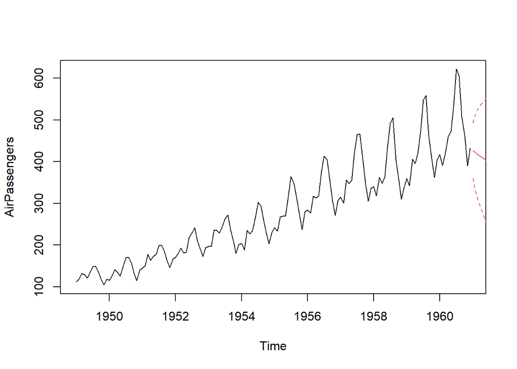

```r
# Run to plot the Nile series plus the forecast and 95% prediction intervals
ts.plot(AirPassengers)
AR_forecast <- predict(AR, n.ahead = 10)$pred
AR_forecast_se <- predict(AR, n.ahead = 10)$se
points(AR_forecast, type = "l", col = 2)
points(AR_forecast - 2*AR_forecast_se, type = "l", col = 2, lty = 2)
points(AR_forecast + 2*AR_forecast_se, type = "l", col = 2, lty = 2)
```

In the object generated by your `predict()` command, the `$pred` value is the forecast, and the `$se` value is the standard error for the forecast.

# Moving Average Model

The simple moving average (MA) model is a parsimonious time series model used to account for very short-run autocorrelation. It does have a regression like form, but here each observation is regressed on the previous innovation, which is not actually observed. Like the autoregressive (AR) model, the MA model includes the white noise (WN) model as special case.

As with previous models, the MA model can be simulated using the `arima.sim()` command by setting the model argument to `list(ma = theta)`, where theta is a slope parameter from the interval (-1, 1). Once again, you also need to specify the series length using the `n` argument.

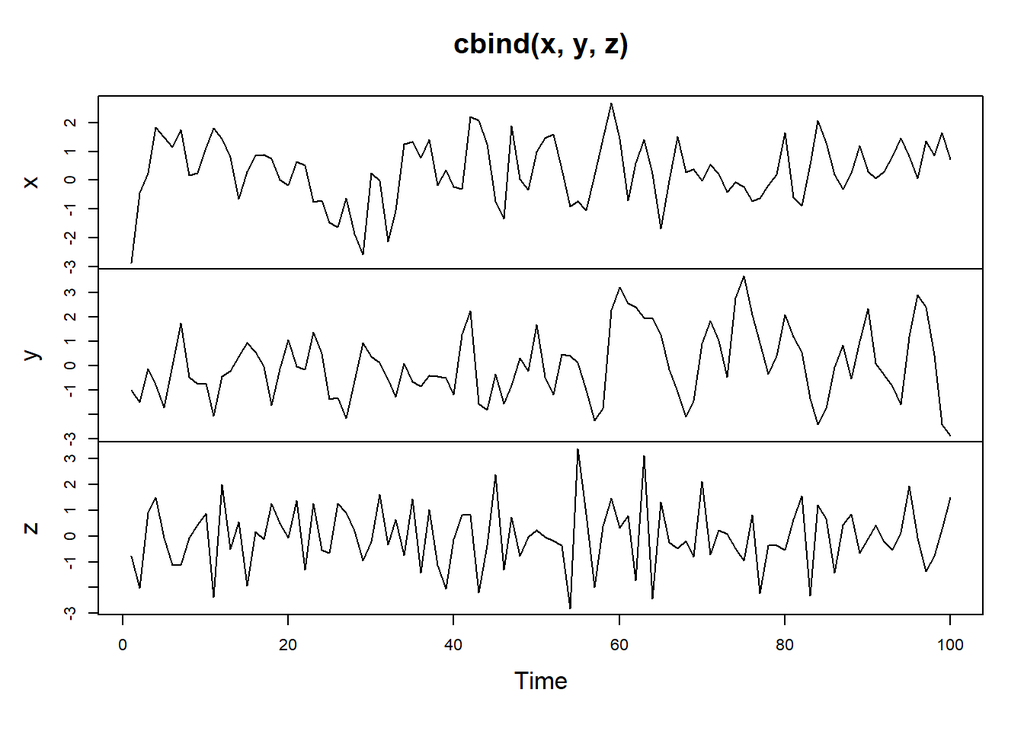

```r
# Generate MA model with slope 0.5
x <- arima.sim(model = list(ma = 0.5), n = 100)

# Generate MA model with slope 0.9
y <- arima.sim(model = list(ma = 0.9), n = 100)

# Generate MA model with slope -0.5
z <- arima.sim(model = list(ma = -0.5), n = 100)

# Plot all three models together
plot.ts(cbind(x, y, z))
```

Note that there is some very short-run persistence for the positive slope values (x and y), and the series has a tendency to alternate when the slope value is negative (z).

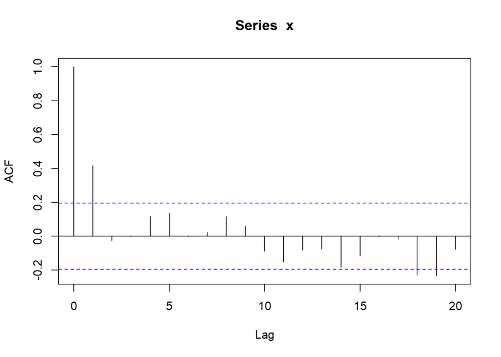

```r
# Calculate ACF for x
acf(x)
```

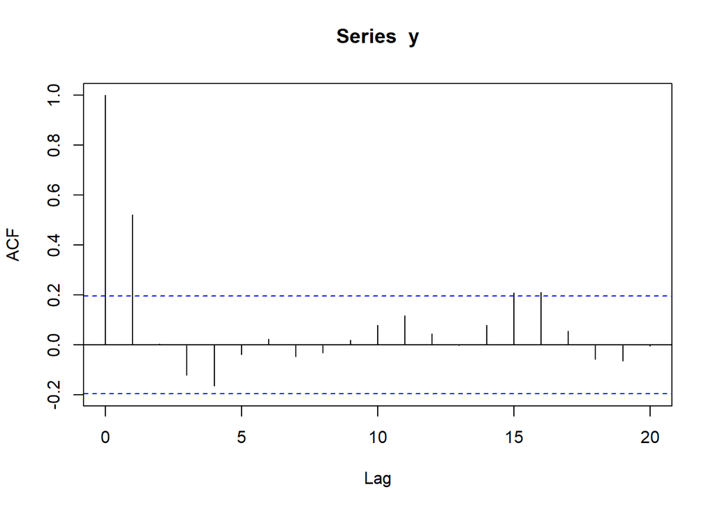

```r
# Calculate ACF for y
acf(y)
```

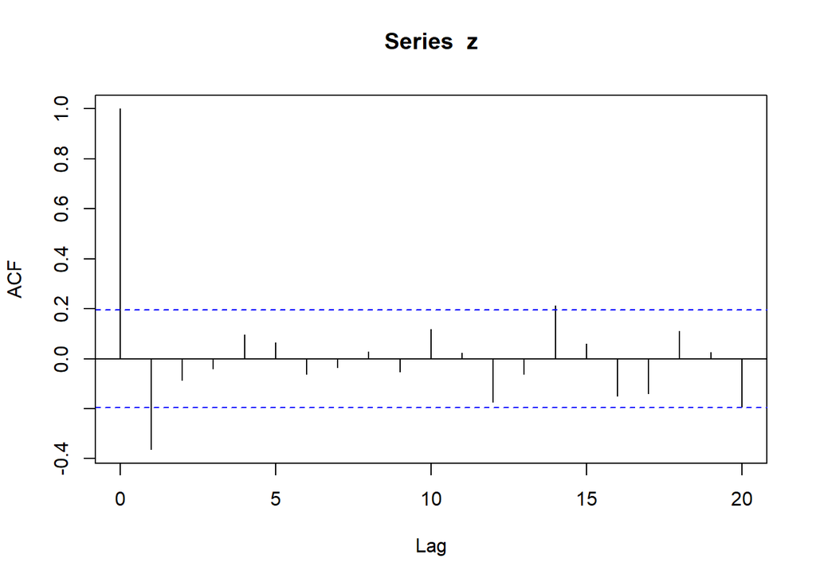

```r
# Calculate ACF for z
acf(z)
```

The series x has positive sample autocorrelation at the first lag, but it is approximately zero at other lags. The series y has a larger sample autocorrelation at its first lag, but it is also approximately zero for the others. The series z has an alternating pattern, and its sample autocorrelation is negative at the first lag. However, similar to the others, it is approximately zero for all higher lags.

The next step is to fit the simple moving average (MA) model to some data using the `arima()` command. For a given time series x we can fit the simple moving average (MA) model using `arima(..., order = c(0, 0, 1))`. Note for reference that an MA model is an ARIMA(0, 0, 1) model.

```r
# Fit the MA model to Nile
MA <- arima(Nile, order = c(0, 0, 1))
print(MA)
```

```
##
## Call:
## arima(x = Nile, order = c(0, 0, 1))
##
## Coefficients:
##          ma1  intercept
##       0.3783   919.2433
## s.e.  0.0791    20.9685
##
## sigma^2 estimated as 23272:  log likelihood = -644.72,  aic = 1295.44
```

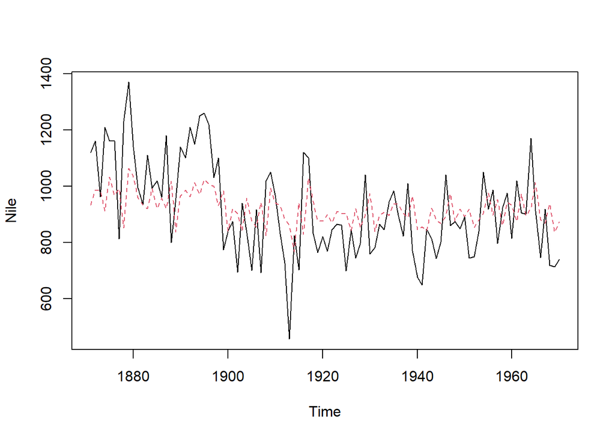

```r
# Plot Nile and MA_fit
ts.plot(Nile)
MA_fit <- Nile - resid(MA)
points(MA_fit, type = "l", col = 2, lty = 2)
```

By fitting an MA model to your Nile data, you’re able to capture variation in the data for future prediction. Based on the plot you’ve generated, does the MA model appear to be a strong fit for the Nile data?

```r
# Make a 1-step forecast based on MA
predict_MA <- predict(MA)

# Obtain the 1-step forecast using $pred[1]
predict_MA$pred[1]
```

```
## [1] 868.8747
```

```r
# Make a 1-step through 10-step forecast based on MA
predict(MA, n.ahead = 10)
```

```
## $pred
## Time Series:
## Start = 1971
## End = 1980
## Frequency = 1
##  [1] 868.8747 919.2433 919.2433 919.2433 919.2433 919.2433 919.2433 919.2433
##  [9] 919.2433 919.2433
##
## $se
## Time Series:
## Start = 1971
## End = 1980
## Frequency = 1
##  [1] 152.5508 163.1006 163.1006 163.1006 163.1006 163.1006 163.1006 163.1006
##  [9] 163.1006 163.1006
```

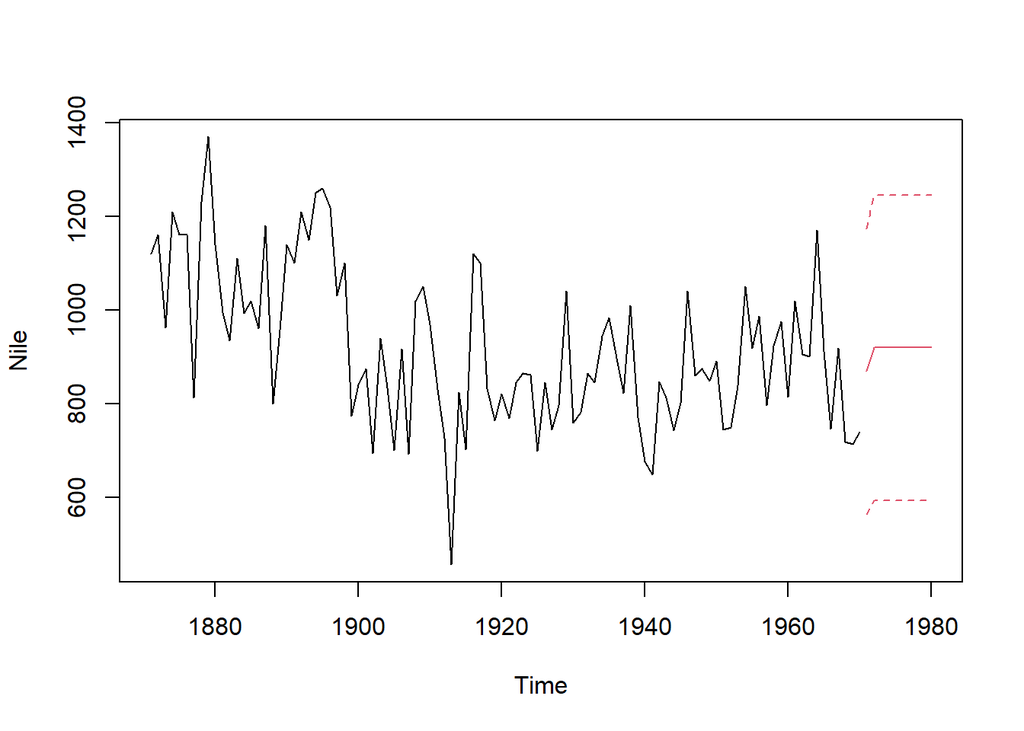

```r
# Plot the Nile series plus the forecast and 95% prediction intervals
ts.plot(Nile, xlim = c(1871, 1980))
MA_forecasts <- predict(MA, n.ahead = 10)$pred
MA_forecast_se <- predict(MA, n.ahead = 10)$se
points(MA_forecasts, type = "l", col = 2)
points(MA_forecasts - 2*MA_forecast_se, type = "l", col = 2, lty = 2)
points(MA_forecasts + 2*MA_forecast_se, type = "l", col = 2, lty = 2)
```

Note that the MA model can only produce a 1-step forecast. For additional forecasting periods, the predict() command simply extends the original 1-step forecast. This explains the unexpected horizontal lines after 1971.

As you’ve seen, autoregressive (AR) and simple moving average (MA) are two useful approaches to modeling time series. But how can you determine whether an AR or MA model is more appropriate in practice?

To determine model fit, you can measure the Akaike information criterion (AIC) and Bayesian information criterion (BIC) for each model.

```r
# Fit the AR model to Nile
AR <- arima(Nile, order = c(1, 0, 0))
AR_fit <- Nile - resid(AR)
```

```r
# Find correlation between AR_fit and MA_fit
cor(AR_fit, MA_fit)
```

```
## [1] 0.9401765
```

```r
# Find AIC of AR
AIC(AR)
```

```
## [1] 1285.904
```

```r
# Find AIC of MA
AIC(MA)
```

```
## [1] 1295.442
```

```r
# Find BIC of AR
BIC(AR)
```

```
## [1] 1293.72
```

```r
# Find BIC of MA
BIC(MA)
```

```
## [1] 1303.257
```

Although the predictions from both models are very similar (indeed, they have a correlation coeffiicent of 0.94), both the AIC and BIC indicate that the AR model is a slightly better fit for your Nile data.